# Report Chile: data_tender work COVID-19

Ruggero Doino

16 October, 2022

# 1 Explore Data

> There are two main datasets: extansive data from the e-procurement portal that gathers all information about bids registered for all tenders, and list of tenders that involved covid-19 purchases.

**E-procurement**

The e-procurement portal gathers all the bids that were registered. First, I exclude 2120026 bids that were not accepted (meaning that for any reasons that were considered not valid by the authorities): being accepted is a necessary but no sufficient condition for winning the tender. I also exclude 5 bids that did not have an identifier.

Then this dataframe gathers information about 1,022,623 tenders such as “Licitation Publica” and “Licitation Privada”, from 2015 to 2021. The analysis will focus only on successful tenders (“Adjudicada”), and thus tenders that went “Cerrada” (1.6 %), “Desierta” (8.3 %), “Revocada” (1.3 %), “Suspendida” (0.011 %) will be excluded. As such, the final sample will account for 908,531 (89 % of the original sample).

> The final sample of interest excludes a tiny portion of bids that cannot be identified with a unique Identifier, a consistent share of bids that were not accepted (different from being selected!), and focusing only on tenders that were awarded.

This dataset contains a wide set of variables summarized in the following list:

- **Tender-level**

| names | Label | Original_names | skim_type | N_obs | n_missing | complete_rate | character.min | character.max | character.empty | character.n_unique | character.whitespace | Date.min | Date.max | Date.median | Date.n_unique | numeric.mean | numeric.sd | numeric.p0 | numeric.p25 | numeric.p50 | numeric.p75 | numeric.p100 | numeric.hist | Description |
| --- | --- | --- | --- | --- | --- | --- | --- | --- | --- | --- | --- | --- | --- | --- | --- | --- | --- | --- | --- | --- | --- | --- | --- | --- |
| DT_TENDER_YEAR |  | year | numeric | 7967 | 0 | 1 |  |  |  |  |  |  |  |  |  | 2022 | 0 | 2022 | 2022 | 2022 | 2022 | 2022 | ▁▁▇▁▁ | Year in which the tender was registered in the e-procurement portal |
| DT_TENDER_MONTH | month tender | month | numeric | 7967 | 0 | 1 |  |  |  |  |  |  |  |  |  | 1 | 0 | 1 | 1 | 1 | 1 | 1 | ▁▁▇▁▁ | Month in which the tender was registered in the e-procurement portal |
| ID_TENDER | tender id index | Codigo | character | 7967 | 0 | 1 | 7 | 7 | 0 | 7967 | 0 |  |  |  |  |  |  |  |  |  |  |  |  | Tender ID that can be used for internal mergings |
| ID_TENDER_EXTERNAL | Tender code refered to external services | CodigoExterno | character | 7967 | 0 | 1 | 9 | 16 | 0 | 7967 | 0 |  |  |  |  |  |  |  |  |  |  |  |  | Código de la Licitación de Mercado Publico: external code that can be used as a reference for Mercado Publico |
| ID_BUYER_RUT | buyer rut | RutUnidad | character | 7967 | 0 | 1 | 12 | 12 | 0 | 996 | 0 |  |  |  |  |  |  |  |  |  |  |  |  | Buyer RUT |
| URL_TENDER | url to tender | Link | character | 7967 | 0 | 1 | 72 | 79 | 0 | 7967 | 0 |  |  |  |  |  |  |  |  |  |  |  |  | URL link for the official page in the e-procurement portal |
| STR_TENDER_NAME | Name of the tender | Nombre | character | 7967 | 0 | 1 | 3 | 255 | 0 | 7826 | 0 |  |  |  |  |  |  |  |  |  |  |  |  | Name of the tender |
| STR_TENDER_DESCRIPTION | Description of the tender | Descripcion | character | 7967 | 0 | 1 | 1 | 264 | 0 | 7406 | 0 |  |  |  |  |  |  |  |  |  |  |  |  | Description of the tender |
| STR_TENDER_TYPE | Type of the tender | Tipo de Adquisicion | character | 7967 | 0 | 1 | 27 | 59 | 0 | 12 | 0 |  |  |  |  |  |  |  |  |  |  |  |  | Type of the tender (string) |
| CAT_TENDER_STATUS | tender status name | Estado | character | 7967 | 0 | 1 | 7 | 34 | 0 | 5 | 0 |  |  |  |  |  |  |  |  |  |  |  |  | There are 5 status ("Adjudicada" "Cerrada" "Desierta (o art. 3 ó 9 Ley 19.886)" "Revocada" "Suspendida" |

[output cut: 45 more lines]

- **Item-level**

| names | Label | Original_names | skim_type | N_obs | n_missing | complete_rate | character.min | character.max | character.empty | character.n_unique | character.whitespace | numeric.mean | numeric.sd | numeric.p0 | numeric.p25 | numeric.p50 | numeric.p75 | numeric.p100 | numeric.hist | Description |
| --- | --- | --- | --- | --- | --- | --- | --- | --- | --- | --- | --- | --- | --- | --- | --- | --- | --- | --- | --- | --- |
| DT_TENDER_YEAR |  | year | numeric | -Inf | 0 | 1 |  |  |  |  |  | 2022 | 0 | 2022 | 2022 | 2022 | 2022 | 2022 | ▁▁▇▁▁ | Year in which the tender was registered in the e-procurement portal |
| DT_TENDER_MONTH | month tender | month | numeric | -Inf | 0 | 1 |  |  |  |  |  | 1 | 0 | 1 | 1 | 1 | 1 | 1 | ▁▁▇▁▁ | Month in which the tender was registered in the e-procurement portal |
| ID_TENDER | tender id index | Codigo | character | -Inf | 0 | 1 | 7 | 7 | 0 | 7967 | 0 |  |  |  |  |  |  |  |  | Tender ID that can be used for internal mergings |
| ID_ITEM_UNSPSC |  | CodigoProductoONU | character | -Inf | 0 | 1 | 8 | 9 | 0 | 4189 | 0 |  |  |  |  |  |  |  |  |  |
| ID_RUT_PARTICIPANT | RUT participant | RutProveedor | character | -Inf | 0 | 1 | 9 | 13 | 0 | 4615 | 0 |  |  |  |  |  |  |  |  | RUT of the participant |
| ID_OFFER |  |  | character | -Inf | 0 | 1 | 10 | 15 | 0 | 39124 | 0 |  |  |  |  |  |  |  |  |  |
| ID_TENDER_EXTERNAL | Tender code refered to external services | CodigoExterno | character | -Inf | 0 | 1 | 9 | 16 | 0 | 7967 | 0 |  |  |  |  |  |  |  |  | Código de la Licitación de Mercado Publico: external code that can be used as a reference for Mercado Publico |
| ID_ITEM |  | Codigoitem | character | -Inf | 0 | 1 | 8 | 8 | 0 | 39124 | 0 |  |  |  |  |  |  |  |  |  |
| STR_ITEM_NAME_GENERAL |  | Nombre producto genrico | character | -Inf | 0 | 1 | 3 | 132 | 0 | 4158 | 0 |  |  |  |  |  |  |  |  | General name of the item purchased |
| STR_ITEM_NAME_SPECIFIC |  | Nombre linea Adquisicion | character | -Inf | 0 | 1 | 3 | 132 | 0 | 4211 | 0 |  |  |  |  |  |  |  |  | Specific name of the item purchased |

[output cut: 4 more lines]

- **Offer-level**

| names | Label | Original_names | skim_type | N_obs | n_missing | complete_rate | character.min | character.max | character.empty | character.n_unique | character.whitespace | Date.min | Date.max | Date.median | Date.n_unique | numeric.mean | numeric.sd | numeric.p0 | numeric.p25 | numeric.p50 | numeric.p75 | numeric.p100 | numeric.hist | Description |
| --- | --- | --- | --- | --- | --- | --- | --- | --- | --- | --- | --- | --- | --- | --- | --- | --- | --- | --- | --- | --- | --- | --- | --- | --- |
| DT_TENDER_YEAR |  | year | numeric | 122336 | 0 | 1 |  |  |  |  |  |  |  |  |  | 2022 | 0 | 2022 | 2022 | 2022 | 2022 | 2022 | ▁▁▇▁▁ | Year in which the tender was registered in the e-procurement portal |
| DT_TENDER_MONTH | month tender | month | numeric | 122336 | 0 | 1 |  |  |  |  |  |  |  |  |  | 1 | 0 | 1 | 1 | 1 | 1 | 1 | ▁▁▇▁▁ | Month in which the tender was registered in the e-procurement portal |
| ID_TENDER | tender id index | Codigo | character | 122336 | 0 | 1 | 7 | 7 | 0 | 7967 | 0 |  |  |  |  |  |  |  |  |  |  |  |  | Tender ID that can be used for internal mergings |
| ID_RUT_PARTICIPANT | RUT participant | RutProveedor | character | 122336 | 0 | 1 | 3 | 13 | 0 | 7842 | 0 |  |  |  |  |  |  |  |  |  |  |  |  | RUT of the participant |
| ID_OFFER |  |  | character | 122336 | 0 | 1 | 10 | 15 | 0 | 122336 | 0 |  |  |  |  |  |  |  |  |  |  |  |  |  |
| ID_TENDER_EXTERNAL | Tender code refered to external services | CodigoExterno | character | 122336 | 0 | 1 | 9 | 16 | 0 | 7967 | 0 |  |  |  |  |  |  |  |  |  |  |  |  | Código de la Licitación de Mercado Publico: external code that can be used as a reference for Mercado Publico |
| ID_ITEM |  | Codigoitem | character | 122336 | 0 | 1 | 8 | 8 | 0 | 39124 | 0 |  |  |  |  |  |  |  |  |  |  |  |  |  |
| AMT_VALUE_ESTIMATED | pode ser item | Monto Estimado Adjudicado | character | 122336 | 9339 | 0.923661064608946 | 1 | 11 | 0 | 5069 | 0 |  |  |  |  |  |  |  |  |  |  |  |  | Total amount of the awarded purchase |
| STR_OFFER_NAME |  | Nombre de la Oferta | character | 122336 | 0 | 1 | 1 | 255 | 0 | 18700 | 0 |  |  |  |  |  |  |  |  |  |  |  |  | Name of the offer |
| AMT_OFFER_QUANTITY |  | Cantidad Ofertada | character | 122336 | 0 | 1 | 1 | 9 | 0 | 1176 | 0 |  |  |  |  |  |  |  |  |  |  |  |  | Total quantity awarded |

[output cut: 9 more lines]

- **Participant-level**

| names | Label | Original_names | skim_type | N_obs | n_missing | complete_rate | character.min | character.max | character.empty | character.n_unique | character.whitespace | Description |
| --- | --- | --- | --- | --- | --- | --- | --- | --- | --- | --- | --- | --- |
| ID_TENDER | tender id index | Codigo | character | 145831 | 0 | 1 | 7 | 7 | 0 | 110182 | 0 | Tender ID that can be used for internal mergings |
| ID_RUT_PARTICIPANT | RUT participant | RutProveedor | character | 145831 | 0 | 1 | 0 | 14 | 1 | 145831 | 0 | RUT of the participant |
| ID_PARTICIPANT_INTERNAL | participant code | CodigoProveedor | character | 145831 | 0 | 1 | 4 | 7 | 0 | 145586 | 0 | Internal ID for the department of the participant |
| ID_SUB_PARTICIPANT_INTERNAL | participant/offer code | CodigoSucursalProveedor | character | 145831 | 0 | 1 | 4 | 7 | 0 | 145831 | 0 | Internal ID for the unit of the participant |
| STR_PARTICIPANT_NAME | participant name | NombreProveedor | character | 145831 | 0 | 1 | 0 | 101 | 81 | 108323 | 0 | Name of the participant |
| STR_PARTICIPANT_LEGAL_NAME | participant formal name | RazonSocialProveedor | character | 145831 | 1 | 0.999993142747427 | 1 | 160 | 0 | 143571 | 0 | Legal name of the participant |
| STR_PARTICIPANT_DESCRIPTION | participant_description | DescripcionProveedor | character | 145831 | 5 | 0.999965713737134 | 1 | 326 | 0 | 137899 | 1 | Description of the participant |

- **Buyer-level**

| names | Label | Original_names | skim_type | N_obs | n_missing | complete_rate | character.min | character.max | character.empty | character.n_unique | character.whitespace | Description |
| --- | --- | --- | --- | --- | --- | --- | --- | --- | --- | --- | --- | --- |
| ID_TENDER | tender id index | Codigo | character | 4236 | 0 | 1 | 7 | 7 | 0 | 4236 | 0 | Tender ID that can be used for internal mergings |
| ID_BUYER_RUT | buyer rut | RutUnidad | character | 4236 | 0 | 1 | 3 | 12 | 0 | 1827 | 0 | Buyer RUT |
| ID_BUYER_DEPARTMENT |  | CodigoOrganismo | character | 4236 | 0 | 1 | 4 | 7 | 0 | 852 | 0 | Responsible organ for tender - code |
| STR_BUYER_NAME |  | NombreOrganismo | character | 4236 | 0 | 1 | 10 | 76 | 0 | 874 | 0 | Responsible organ for tender - name |
| STR_BUYER_SECTOR |  | sector | character | 4236 | 0 | 1 | 4 | 27 | 0 | 8 | 0 | Type of the buyer |
| ID_BUYER_UNIT | buyer id index | CodigoUnidad | character | 4236 | 0 | 1 | 4 | 7 | 0 | 4211 | 0 | Buyer ID unit |
| STR_BUYER_UNIT | buyer name | NombreUnidad | character | 4236 | 0 | 1 | 3 | 80 | 0 | 4236 | 0 | Buyer name unit |
| STR_BUYER_ADDRESS | buyer street name | DireccionUnidad | character | 4236 | 1 | 0.999763928234183 | 0 | 155 | 149 | 3561 | 0 | Buyer unit address |
| STR_BUYER_CITY | buyer | ComunaUnidad | character | 4236 | 0 | 1 | 0 | 26 | 171 | 330 | 0 | Buyer unit city |
| STR_BUYER_REGION |  | RegionUnidad | character | 4236 | 0 | 1 | 16 | 48 | 0 | 16 | 0 | Buyer unit region |

**Covid portal**

First, I download COVID-19 data_tender from [here](https://app.powerbi.com/view?r=eyJrIjoiNmU2NzBkNzUtYmM1Mi00NGVmLTljYWQtNTIxNTlhMTQ4ZjQ5IiwidCI6ImIwMGQ1ZjQ5LTk4YWMtNGJjNS1hMmM5LWNhZmRmNzEyMTZmMCIsImMiOjR9). The repository contains two files: “OC_COVID19.csv” (tenders related to COVID-19 emergency) and “OCItem_COVID19.csv” (list of items related to COVID-19 emergency). From now on, I will call these datasets tender-level and item-level emergency datasets, while the ordinary full sample of tenders prepared by Leandro will be called chile_compra datasets. This dataset gathers information about 10,491 tenders with the following set of variables:

- Tender-level: description, title, no date of publication/query/award/payment, type, buyer characteristics.
- Item-level: quantity, price, only date of delivery, UNSPSC code, description.
- Participant-level: no bid information.

# 2 How do we get to the final sample?

**Merging two datasets**

The emergency portal can only partially help us to identify which tenders are covid-related since the merging rate with the main sample is only 42 %.

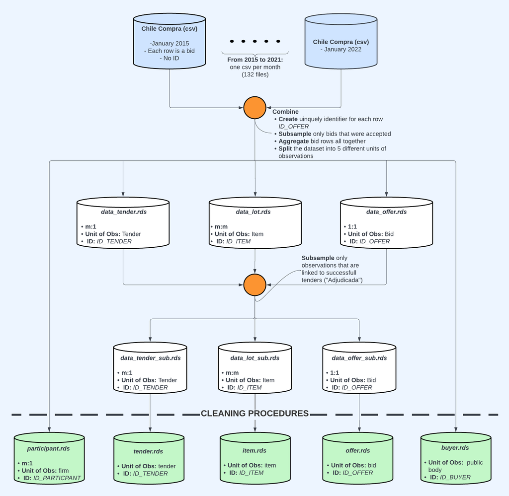

# 3 Data Cleaning

## 3.1 Offer Value - *AMT_VALUE_AWARDED*

> I replace all negative numbers as missing values.

I replace 24 values as missing: they are negative numbers.

> I replace irregular cases as missing.

475 observations present the following irregularity: quantity awarded is equal to total price offered (very weird) plus the value awarded is the product of these two terms (even more weird). After checking a sample of 10 cases, I realize that the value awarded is equal to the price offered. I replace them.

| DT_TENDER_YEAR | DT_TENDER_MONTH | ID_TENDER | ID_RUT_PARTICIPANT | ID_OFFER | ID_TENDER_EXTERNAL | ID_ITEM | AMT_VALUE_ESTIMATED | STR_OFFER_NAME | AMT_OFFER_QUANTITY | CAT_OFFER_CURRENCY | AMT_PRICE_UNIT | AMT_TOTAL_PRICE | AMT_QUANTITY_AWARDED | AMT_VALUE_AWARDED | DT_OFFER_SEND | IND_OFFER_WIN | ID_ITEM_UNSPSC | ID_BUYER_RUT | tender_covid_19 |
| --- | --- | --- | --- | --- | --- | --- | --- | --- | --- | --- | --- | --- | --- | --- | --- | --- | --- | --- | --- |
| 2015 | 1 | 7581176 | 6.451.100-9 | 32506037_41346 | 1553-6-L115 | 32506037 | 1380230 | Licitacion 1553-6-L114 | 1 | Peso Chileno | 1490 | 1490 | 1490 | 2220100 | 2015-01-12 | 1 | 72131702 | 61.607.502-0 | 0 |
| 2015 | 1 | 7580912 | 76.830.090-9 | 32506384_156848 | 5325-4-LE15 | 32506384 | 252 | AND5325-4-LE15 | 1 | Peso Chileno | 7 | 7 | 7 | 49 | 2015-01-20 | 1 | 51191515 | 69.050.400-6 | 0 |
| 2015 | 1 | 7558376 | 88.597.500-3 | 32477056_192196 | 812030-49-LP14 | 32477056 | 16916 | Laboratorio Biosano S.A | 1 | Peso Chileno | 37 | 37 | 37 | 1369 | 2015-01-22 | 1 | 50202301 | 65.075.485-9 | 0 |
| 2015 | 1 | 7583245 | 9.983.363-7 | 32518766_195523 | 4081-1-LP15 | 32518766 | 553616 | munic cabrero | 1 | Peso Chileno | 553616 | 553616 | 553616 | 306490675456 | 2015-01-22 | 1 | 44122016 | 69.151.001-8 | 0 |
| 2015 | 1 | 7580017 | 96.659.920-0 | 32502327_233669 | 2421-4-LP15 | 32502327 | 113445378 | BIOMERIEUX CHILE S.A. | 1 | Peso Chileno | 9500 | 9500 | 9500 | 90250000 | 2015-01-26 | 1 | 41116004 | 69.256.900-8 | 0 |
| 2015 | 1 | 7590835 | 8.980.404-3 | 32567150_322188 | 4594-5-LE15 | 32567150 | 1755548 | FOMULARIOS DE CALIDAD | 1 | Peso Chileno | 1250 | 1250 | 1250 | 1562500 | 2015-01-30 | 1 | 82121507 | 69.141.102-8 | 0 |
| 2015 | 1 | 7761806 | 77.606.220-0 | 33568438_362232 | 2421-150-R115 | 33568438 | 1,2e+08 | PROPUESTA SASF - DIVISÓN MÉDICA | 1 | Peso Chileno | 5 | 5 | 5 | 25 | 2015-02-02 | 1 | 24111502 | 69.256.900-8 | 0 |
| 2015 | 2 | 7609549 | 96.756.540-7 | 32683031_126679 | 4463-27-LE15 | 32683031 | 963000 | B.BRAUN MEDICAL SpA | 1 | Peso Chileno | 3750 | 3750 | 3750 | 14062500 | 2015-02-17 | 1 | 42142502 | 61.606.903-9 | 0 |
| 2015 | 2 | 7610662 | 77.596.940-7 | 32685829_143479 | 3806-2-L115 | 32685829 | 4188649 | MEDICAMENTOS E INSUMOS | 1 | Peso Chileno | 500 | 500 | 500 | 250000 | 2015-02-18 | 1 | 51171904 | 69.120.200-3 | 0 |
| 2015 | 2 | 7610662 | 77.596.940-7 | 32688279_143713 | 3806-2-L115 | 32688279 | 4188649 | MEDICAMENTOS E INSUMOS | 1 | Peso Chileno | 300 | 300 | 300 | 90000 | 2015-02-18 | 1 | 51142012 | 69.120.200-3 | 0 |

[output cut: 465 more lines]

> I replace the rest of irregular cases as missing.

65735 observations present the following irregularity: AMT_QUANTITY_AWARDED, AMT_VALUE_AWARDED and AMT_TOTAL_PRICE are equal to 1. Then, I code as missings since I believe they are all mistypes.

| DT_TENDER_YEAR | DT_TENDER_MONTH | ID_TENDER | ID_RUT_PARTICIPANT | ID_OFFER | ID_TENDER_EXTERNAL | ID_ITEM | AMT_VALUE_ESTIMATED | STR_OFFER_NAME | AMT_OFFER_QUANTITY | CAT_OFFER_CURRENCY | AMT_PRICE_UNIT | AMT_TOTAL_PRICE | AMT_QUANTITY_AWARDED | AMT_VALUE_AWARDED | DT_OFFER_SEND | IND_OFFER_WIN | ID_ITEM_UNSPSC | ID_BUYER_RUT | tender_covid_19 |
| --- | --- | --- | --- | --- | --- | --- | --- | --- | --- | --- | --- | --- | --- | --- | --- | --- | --- | --- | --- |
| 2019 | 8 | 8566464 | 76.094.395-9 | 38033460_207529 | 2101-61-LQ19 | 38033460 | 145783655 | OFERTA EXAMENES DE ALTO COSTO NO GES HOSPITAL INTERCULTURAL KALLVU LLANKA | 1 | Peso Chileno | 1 | 1 | 1 | 1 | 2019-09-16 | 1 | 85122201 | 61.602.213-k | 0 |
| 2015 | 12 | 7847809 | 76.236.734-3 | 34016688_190367 | 4197-55-L115 | 34016688 | 52 | MANTENCION Y REPARACION AMBULANCIAS DEPTO. SALUD QUEMCHI | 1 | Peso Chileno | 1 | 1 | 1 | 1 | 2015-12-29 | 1 | 78180102 | 69.230.200-1 | 0 |
| 2015 | 3 | 7635121 | 12.816.712-9 | 32854573_328045 | 744-1-LE15 | 32854573 | 850032 | ARRIENDO DE VEHICULO | 1 | Peso Chileno | 1 | 1 | 1 | 1 | 2015-03-30 | 1 | 78111808 | 60.703.000-6 | 0 |
| 2022 | 1 | 8903966 | 76.751.201-5 | 39684494_26645 | 2566-52-LE21 | 39684494 | 3 | C.S. Mantenimiento y Reparación Sistemas Eléctricos DAEM CHEPICA | 1 | Peso Chileno | 1 | 1 | 1 | 1 | 2022-01-18 | 1 | 39121311 | 69.090.700-3 | 0 |
| 2021 | 4 | 8798834 | 15.009.829-7 | 39183043_48485 | 898115-1-LE21 | 39183043 | 1 | CONVENIO DE SUMINISTRO DE ALIMENTOS PARA RF ARICA | 1 | Peso Chileno | 1 | 1 | 1 | 1 | 2021-04-21 | 1 | 93131608 | 61.008.000-6 | 0 |
| 2019 | 5 | 8500698 | 25.190.232-1 | 37687091_144338 | 4465-11-LE19 | 37687091 | 4,8e+07 | Compra de servicios médicos de llamado para prestaciones específicas de Traumatología | 1 | Peso Chileno | 1 | 1 | 1 | 1 | 2019-05-29 | 1 | 80111606 | 61.606.903-9 | 0 |
| 2018 | 1 | 8288341 | 76.777.940-2 | 36536923_262810 | 2324-19-LR18 | 36536923 | 120015 | CONVENIO DE SUMINISTRO DE ARIDOS TUBOS CORRUGADOS Y SERVICIO DE ARRIENDO MAQUINARIA PESADA MUNICIPALIDAD DE PUERTO MONTT | 1 | Peso Chileno | 1 | 1 | 1 | 1 | 2018-03-05 | 1 | 24101510 | 69.220.100-0 | 0 |
| 2016 | 6 | 7961322 | 76.334.992-6 | 34699239_235735 | 3611-23-LE16 | 34699239 | 3 | Mantenciones preventivas y correctivas para vehículos | 1 | Peso Chileno | 1 | 1 | 1 | 1 | 2016-06-30 | 1 | 78180103 | 69.190.600-0 | 0 |
| 2017 | 7 | 8179520 | 77.596.940-7 | 35962209_1395 | 2284-178-L117 | 35962209 | 4674000 | 2284-178-L117 LABORATORIO CHILE S.A. | 1 | Peso Chileno | 1 | 1 | 1 | 1 | 2017-07-05 | 1 | 51142405 | 69.200.100-1 | 0 |
| 2015 | 12 | 7795611 | 76.384.335-1 | 33747810_255486 | 2239-22-LR15 | 33747810 | 379 | Oferta Importadora y Comercializadora LRL SpA | 1 | Peso Chileno | 1 | 1 | 1 | 1 | 2016-01-21 | 1 | 25172504 | 60.808.000-7 | 0 |

> I convert all the values in USD following the instructions provided on the [Chile Compra](https://transparenciachc.blob.core.windows.net/oc-da/ParidadMoneda.csv) platform.

> I trim the values at the 99th percentile.

# 4 Task 1

**Define variable: medical equipment** We can define items as medical equipment following the UNSPC code: item codes that start with “42” are considered as such. The following table shows the distribution of “Medical Equipment” among “Tender Emergency”.

Frequency table: medical equipment among emergency tenders

| Medical Equipment | Emergency Tender |
| --- | --- |
| 0 | 67571 (72%) |
| 1 | 25980 (28%) |
| Total | 93551 (100%) |

> Composition of tenders by type of item (only covid-19 items purchased): all UNSPSC digits

| ID_ITEM_UNSPSC | AMT_VALUE_AWARDED_99_EMERGENCY | N_TENDERS_EMERGENCY | AMT_VALUE_AWARDED_99_ALL | N_TENDERS_ALL | PCT_VALUE_EMERGENCY | PCT_CONTRACT_EMERGENCY | type_of_equipment | ID_ITEM_DESCRIPTION |
| --- | --- | --- | --- | --- | --- | --- | --- | --- |
| 10101502 | 459.00 | 1.00 | 61104.00 | 14.00 | 1.00 | 7.00 | Non-medical | Artículos para plantas y animales |
| 10101510 | 4541.00 | 2.00 | 21450.00 | 14.00 | 21.00 | 14.00 | Non-medical | Artículos para plantas y animales |
| 10101516 | 51777.00 | 3.00 | 119813.00 | 14.00 | 43.00 | 21.00 | Non-medical | Artículos para plantas y animales |
| 10101704 | 84333.00 | 11.00 | 328555.00 | 71.00 | 26.00 | 15.00 | Non-medical | Artículos para plantas y animales |
| 10111302 | 1.00 | 1.00 | 555106.00 | 130.00 | 0.00 | 1.00 | Non-medical | Artículos para plantas y animales |
| 10111305 | 32467.00 | 44.00 | 2766233.00 | 3131.00 | 1.00 | 1.00 | Non-medical | Artículos para plantas y animales |
| 10121501 | 77.00 | 1.00 | 35877.00 | 11.00 | 0.00 | 9.00 | Non-medical | Artículos para plantas y animales |
| 10121502 | 696.00 | 1.00 | 280716.00 | 26.00 | 0.00 | 4.00 | Non-medical | Artículos para plantas y animales |
| 10121505 | 18288.00 | 1.00 | 1556219.00 | 99.00 | 1.00 | 1.00 | Non-medical | Artículos para plantas y animales |
| 10121506 | 19.00 | 1.00 | 169.00 | 6.00 | 11.00 | 17.00 | Non-medical | Artículos para plantas y animales |

[output cut: 3716 more lines]

> Composition of tenders by type of item (only covid-19 items purchased): 6 UNSPSC digits

| ID_ITEM_UNSPSC | AMT_VALUE_AWARDED_99_EMERGENCY | N_TENDERS_EMERGENCY | AMT_VALUE_AWARDED_99_ALL | N_TENDERS_ALL | PCT_VALUE_EMERGENCY | PCT_CONTRACT_EMERGENCY | type_of_equipment | ID_ITEM_DESCRIPTION |
| --- | --- | --- | --- | --- | --- | --- | --- | --- |
| 101015 | 56777.00 | 6.00 | 1070712.00 | 180.00 | 5.00 | 3.00 | Non-medical | Animales domésticos |
| 101017 | 84333.00 | 11.00 | 357302.00 | 86.00 | 24.00 | 13.00 | Non-medical | Peces |
| 101113 | 32468.00 | 45.00 | 3438548.00 | 3311.00 | 1.00 | 1.00 | Non-medical | Accesorios y tratamientos para mascotas |
| 101215 | 19080.00 | 4.00 | 1934778.00 | 149.00 | 1.00 | 3.00 | Non-medical | Alimento para ganado |
| 101218 | 1.00 | 1.00 | 161067.00 | 61.00 | 0.00 | 2.00 | Non-medical | Alimento para perros y gatos |
| 101316 | 387.00 | 2.00 | 61669.00 | 62.00 | 1.00 | 3.00 | Non-medical | Refugio para animales |
| 101416 | 2371.00 | 6.00 | 197066.00 | 116.00 | 1.00 | 5.00 | Non-medical | Arneses |
| 101515 | 27463.00 | 33.00 | 896747.00 | 1125.00 | 3.00 | 3.00 | Non-medical | Semillas y almácigos |
| 101516 | 8763.00 | 19.00 | 146713.00 | 125.00 | 6.00 | 15.00 | Non-medical | Semillas de cereales |
| 101517 | 43005.00 | 8.00 | 1158358.00 | 190.00 | 4.00 | 4.00 | Non-medical | Semillas y almácigos de hierbas y forraje |

[output cut: 1142 more lines]

> Composition of tenders by type of item (only covid-19 items purchased): 4 UNSPSC digits

| ID_ITEM_UNSPSC | AMT_VALUE_AWARDED_99_EMERGENCY | N_TENDERS_EMERGENCY | AMT_VALUE_AWARDED_99_ALL | N_TENDERS_ALL | PCT_VALUE_EMERGENCY | PCT_CONTRACT_EMERGENCY | type_of_equipment | ID_ITEM_DESCRIPTION |
| --- | --- | --- | --- | --- | --- | --- | --- | --- |
| 1010 | 141110.00 | 17.00 | 1554518.00 | 355.00 | 9.00 | 5.00 | Non-medical | Animales vivos |
| 1011 | 32468.00 | 45.00 | 5056390.00 | 3330.00 | 1.00 | 1.00 | Non-medical | Artículos para mascotas |
| 1011 | 32468.00 | 45.00 | 5056390.00 | 3330.00 | 1.00 | 1.00 | Non-medical | Obras |
| 1011 | 32468.00 | 45.00 | 5056390.00 | 3330.00 | 1.00 | 1.00 | Non-medical | Obras Mayores |
| 1011 | 32468.00 | 45.00 | 5056390.00 | 3330.00 | 1.00 | 1.00 | Non-medical | Obras Menores |
| 1012 | 19080.00 | 5.00 | 2370167.00 | 305.00 | 1.00 | 2.00 | Non-medical | Alimento para animales |
| 1013 | 387.00 | 2.00 | 69991.00 | 73.00 | 1.00 | 3.00 | Non-medical | Casas y jaulas para animales |
| 1014 | 2371.00 | 6.00 | 259756.00 | 133.00 | 1.00 | 5.00 | Non-medical | Artículos de talabartería y arreos |
| 1015 | 92790.00 | 82.00 | 2681886.00 | 1782.00 | 3.00 | 5.00 | Non-medical | Semillas, bulbos y almácigos |
| 1016 | 2431.00 | 6.00 | 966852.00 | 502.00 | 0.00 | 1.00 | Non-medical | Productos de floricultura y silvicultura |

[output cut: 276 more lines]

> Composition of tenders by type of item (only covid-19 items purchased): 2 UNSPSC digits

| ID_ITEM_UNSPSC | AMT_VALUE_AWARDED_99_EMERGENCY | N_TENDERS_EMERGENCY | AMT_VALUE_AWARDED_99_ALL | N_TENDERS_ALL | PCT_VALUE_EMERGENCY | PCT_CONTRACT_EMERGENCY | type_of_equipment | ID_ITEM_DESCRIPTION |
| --- | --- | --- | --- | --- | --- | --- | --- | --- |
| 10 | 1071491.00 | 205.00 | 21472766.00 | 7904.00 | 5.00 | 3.00 | Non-medical | Artículos para plantas y animales |
| 10 | 1071491.00 | 205.00 | 21472766.00 | 7904.00 | 5.00 | 3.00 | Non-medical | Obras |
| 10 | 1071491.00 | 205.00 | 21472766.00 | 7904.00 | 5.00 | 3.00 | Non-medical | Consultoria |
| 10 | 1071491.00 | 205.00 | 21472766.00 | 7904.00 | 5.00 | 3.00 | Non-medical | eCommerce |
| 11 | 1154656.00 | 469.00 | 38618740.00 | 12591.00 | 3.00 | 4.00 | Non-medical | Productos derivados de minerales, plantas y animales |
| 12 | 1602744.00 | 1171.00 | 13669026.00 | 11510.00 | 12.00 | 10.00 | Non-medical | Productos químicos industriales |
| 13 | 108111.00 | 123.00 | 4131399.00 | 2421.00 | 3.00 | 5.00 | Non-medical | Resinas, cauchos, espumas y elastómeros |
| 14 | 940394.00 | 536.00 | 12098034.00 | 9495.00 | 8.00 | 6.00 | Non-medical | Productos de papel |
| 15 | 183991.00 | 113.00 | 5649791.00 | 2731.00 | 3.00 | 4.00 | Non-medical | Combustibles, lubricantes y anticorrosivos |
| 20 | 598237.00 | 92.00 | 10381948.00 | 1955.00 | 6.00 | 5.00 | Non-medical | Maquinaria para minería y perforación |

[output cut: 48 more lines]

# 5 Task 2

# 6 Task 3